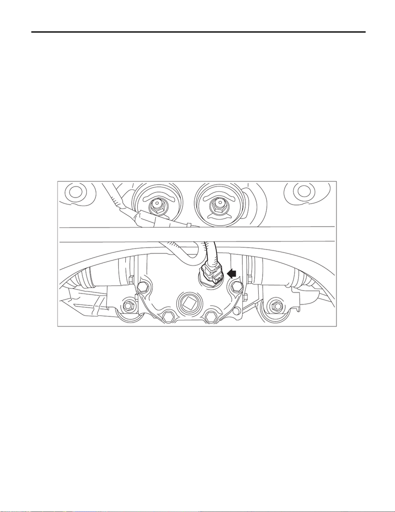

EC(STI)-7

Canister

EMISSION CONTROL (AUX. EMISSION CONTROL DEVICES)

4. Canister

A: REMOVAL

WARNING:

Place “NO OPEN FLAMES” signs near the working area.

CAUTION:

Be careful not to spill fuel.

1) Release the fuel pressure. <Ref. to FU(STI)-64, RELEASING OF FUEL PRESSURE, PROCEDURE, Fu-

el.>

2) Drain fuel. <Ref. to FU(STI)-64, DRAINING FUEL (WITH SUBARU SELECT MONITOR), PROCEDURE,

Fuel.>

3) Disconnect the ground cable from battery.

4) Lift up the vehicle.

5) Remove the rear exhaust pipe. <Ref. to EX(STI)-12, REMOVAL, Rear Exhaust Pipe.>

6) Remove the propeller shaft. <Ref. to DS-12, REMOVAL, Propeller Shaft.>

7) Support the rear differential with the transmission jack.

8) Disconnect the connector from oil temperature sensor.

EC-03445

15WRX_STI_US_EN.book 7 ページ ２０１５年２月１３日 金曜日 午前１１時２０分

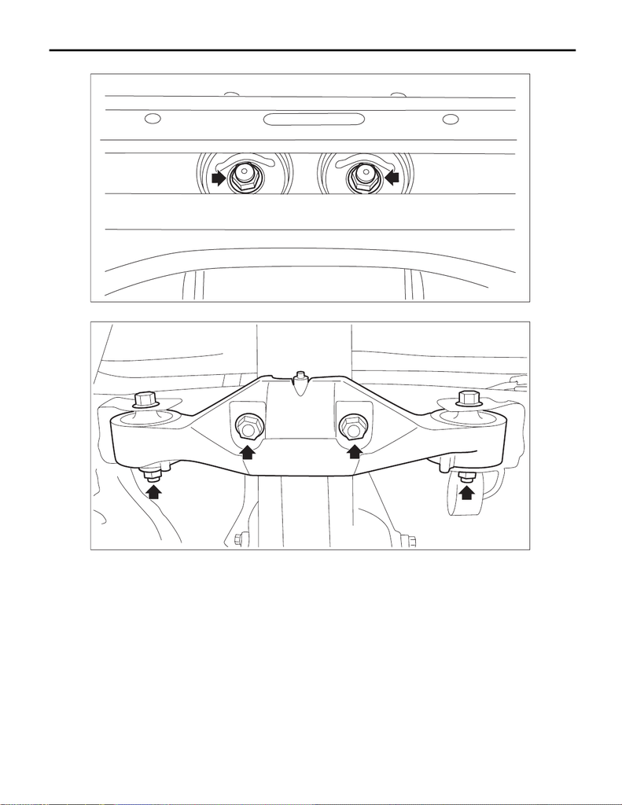

EC(STI)-8

Canister

EMISSION CONTROL (AUX. EMISSION CONTROL DEVICES)

9) Remove the self-locking nuts which hold the rear differential to the rear sub frame assembly.

10) Remove the rear differential member from the rear sub frame assembly and the rear differential.

EC-03420

EC-03453

15WRX_STI_US_EN.book 8 ページ ２０１５年２月１３日 金曜日 午前１１時２０分

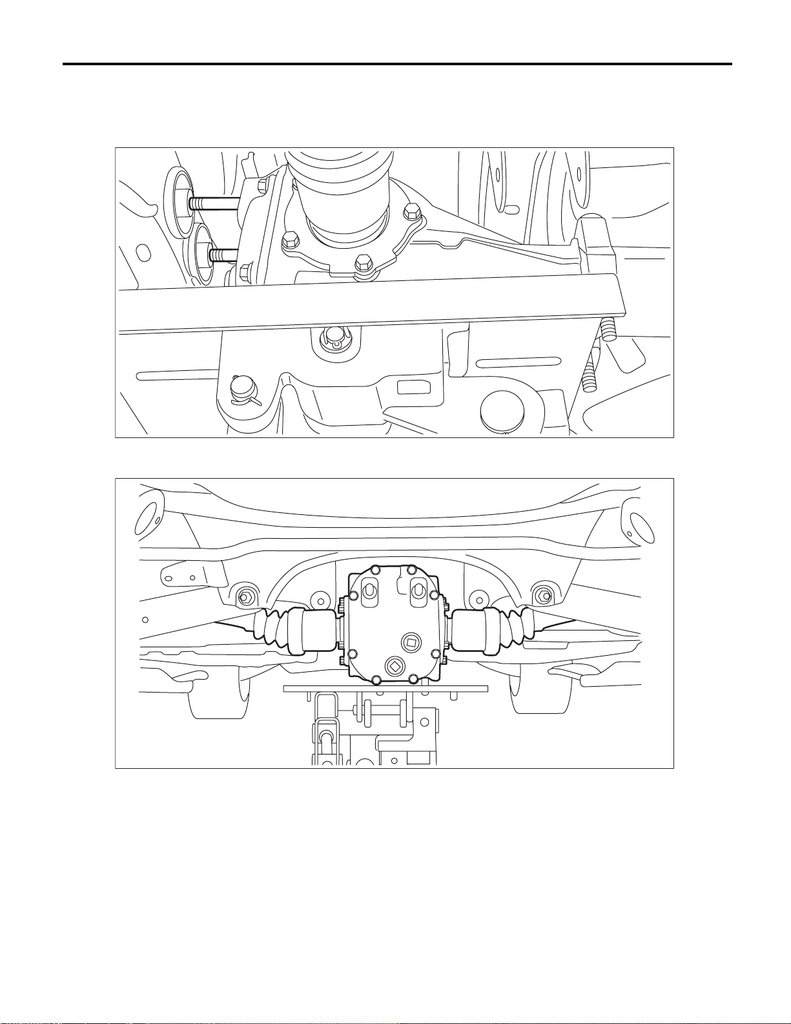

EC(STI)-9

Canister

EMISSION CONTROL (AUX. EMISSION CONTROL DEVICES)

11) Lower the transmission jack gradually until the rear differential is at the position shown in the figure.

NOTE:

• When pulling out the stud bolt from the bushing portion of the rear sub frame assembly, adjust the angle

and location of transmission jack and jack stand.

• Do not lower the rear differential excessively. Doing so may add extra load to the drive shaft or cause the

falling-off of the drive shaft.

EC-03320

EC-03421

15WRX_STI_US_EN.book 9 ページ ２０１５年２月１３日 金曜日 午前１１時２０分

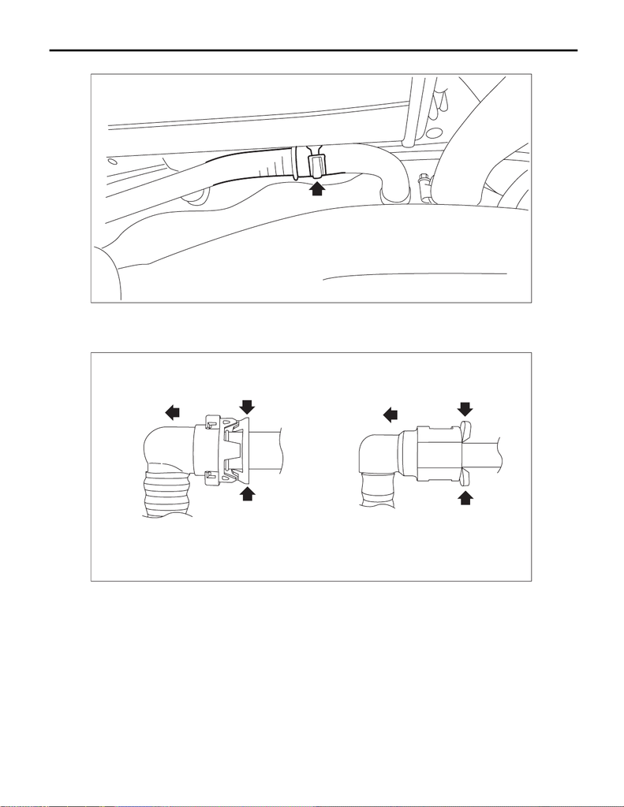

EC(STI)-10

Canister

EMISSION CONTROL (AUX. EMISSION CONTROL DEVICES)

12) Disconnect the vent tube from vent hose.

13) Disconnect the drain tube (A) and purge tube (B) from the canister.

NOTE:

Disconnect the quick connector as shown in the figure.

(a) Drain tube (b) Purge tube

EC-03422

EC-02971

(a)

(b)

1

1

2

1

1

2

15WRX_STI_US_EN.book 10 ページ ２０１５年２月１３日 金曜日 午前１１時２０分

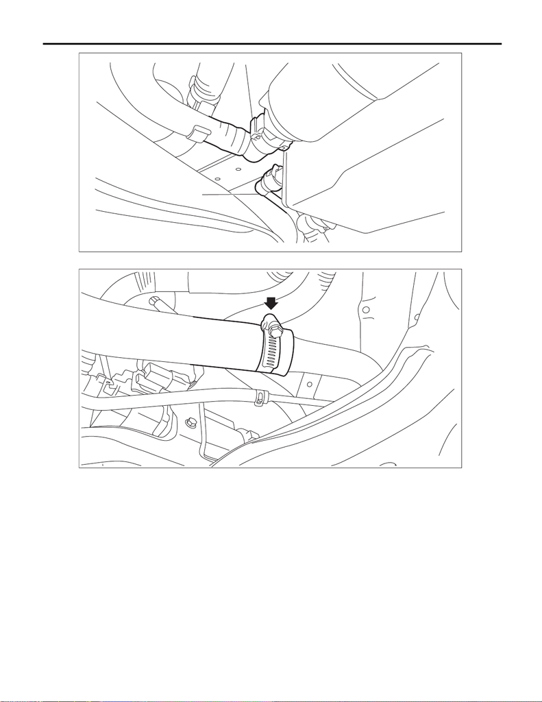

EC(STI)-11

Canister

EMISSION CONTROL (AUX. EMISSION CONTROL DEVICES)

14) Disconnect the fuel filler hose from the fuel filler pipe assembly.

(A)

(B)

EC-03423

FU-08361

15WRX_STI_US_EN.book 11 ページ ２０１５年２月１３日 金曜日 午前１１時２０分

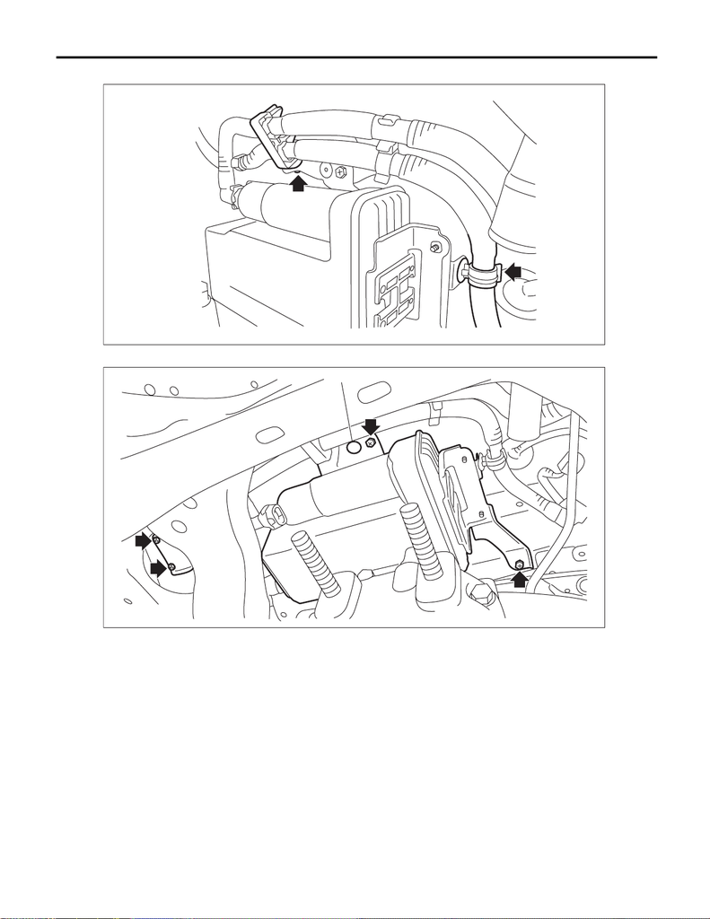

EC(STI)-12

Canister

EMISSION CONTROL (AUX. EMISSION CONTROL DEVICES)

15) Remove the tube clamp from the canister bracket A, and remove the drain tube from the tube clamp.

16) Remove the bolts and clip (A) securing the canister to the vehicle, and remove the canister.

EC-03428

(A)

EC-03424

15WRX_STI_US_EN.book 12 ページ ２０１５年２月１３日 金曜日 午前１１時２０分

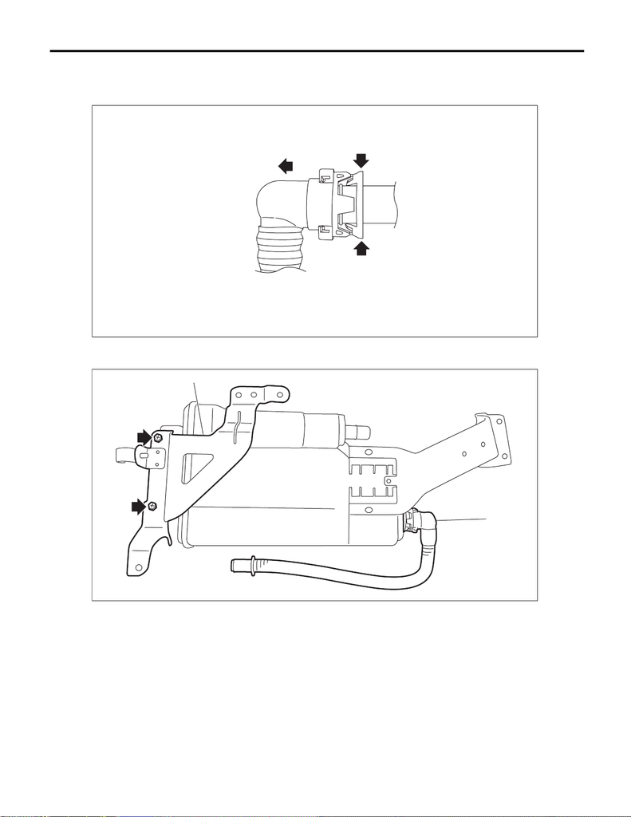

EC(STI)-13

Canister

EMISSION CONTROL (AUX. EMISSION CONTROL DEVICES)

17) Disconnect the vent tube (B) from the canister and remove the canister bracket A (A).

NOTE:

• Disconnect the quick connector as shown in the figure.

• The canister bracket cannot be separated from the canister. Therefore, be sure to replace both of them

with new ones when replacing the canister or canister bracket.

EC-02999

1

1

2

(A)

(B)

EC-03426

15WRX_STI_US_EN.book 13 ページ ２０１５年２月１３日 金曜日 午前１１時２０分

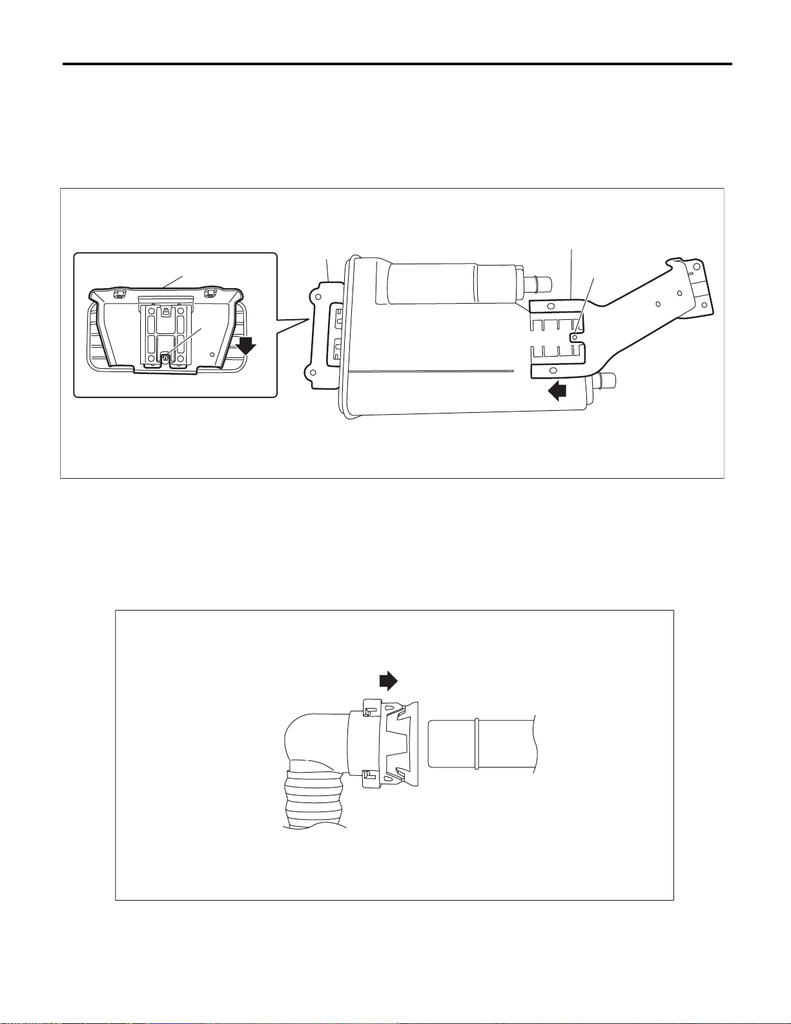

EC(STI)-14

Canister

EMISSION CONTROL (AUX. EMISSION CONTROL DEVICES)

B: INSTALLATION

1) Move it in the direction of the arrow and install the canister bracket B (A) and canister bracket C (B) to the

canister.

NOTE:

• Use a new canister and a canister bracket.

• Check that the claw (a) is securely tightened.

CAUTION:

• Check that there is no damage or dust on the quick connector. If necessary, clean the seal surface

of the pipe.

• Make sure that the quick connector is securely connected.

NOTE:

Install the quick connector as shown in the figure.

EC-03427

(B)

(a)

(A)

(a)

(A)

EC-03000

15WRX_STI_US_EN.book 14 ページ ２０１５年２月１３日 金曜日 午前１１時２０分

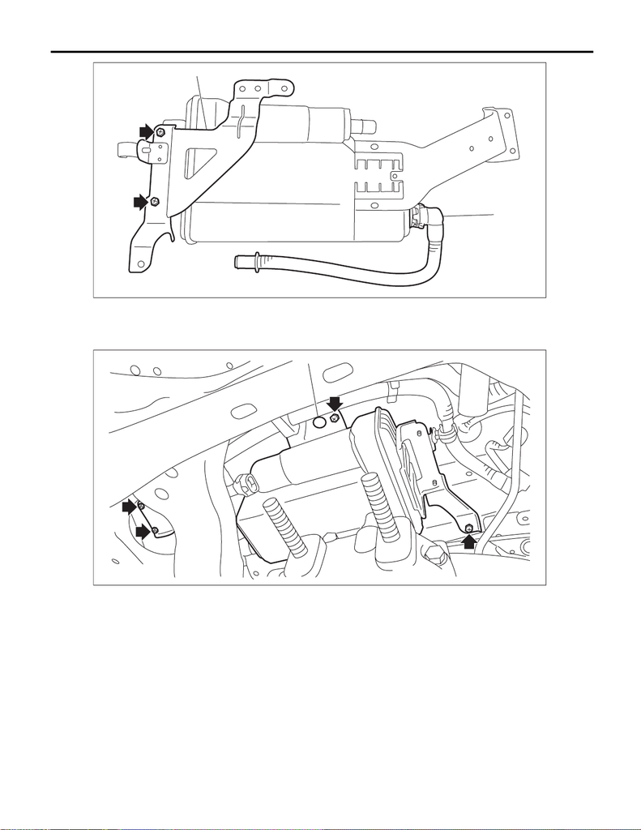

EC(STI)-15

Canister

EMISSION CONTROL (AUX. EMISSION CONTROL DEVICES)

3) Set the canister to the vehicle, and attach the bolts and clip (A) which secure the canister.

Tightening torque:

7.5 N·m (0.8 kgf-m, 5.5 ft-lb)

(A)

(B)

EC-03426

(A)

EC-03424

15WRX_STI_US_EN.book 15 ページ ２０１５年２月１３日 金曜日 午前１１時２０分

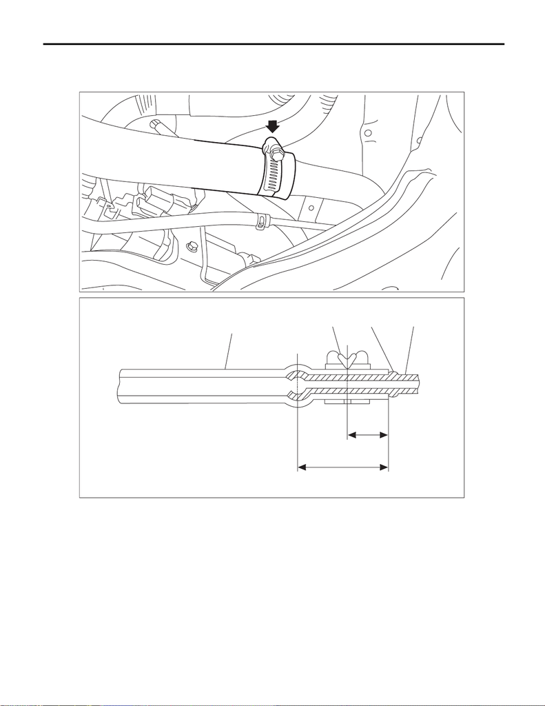

EC(STI)-16

Canister

EMISSION CONTROL (AUX. EMISSION CONTROL DEVICES)

4) Correctly insert the fuel filler hose to the spool, and then install the clamp as shown.

Tightening torque:

2.5 N·m (0.3 kgf-m, 1.8 ft-lb)

(1) Hose (3) Spool (4) Pipe

(2) Clamp

FU-08361

L

L/2

(1)

(2)

(3)

(4)

FU-06185

15WRX_STI_US_EN.book 16 ページ ２０１５年２月１３日 金曜日 午前１１時２０分

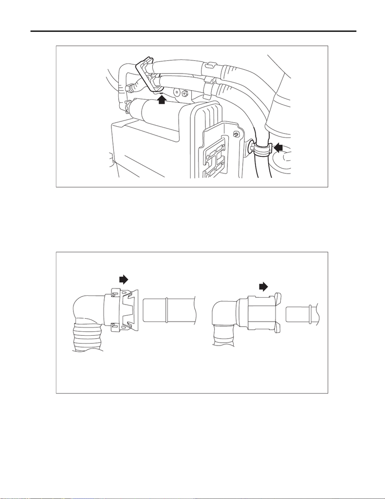

EC(STI)-17

Canister

EMISSION CONTROL (AUX. EMISSION CONTROL DEVICES)

5) Install the tube clamp to the canister bracket A, and install the drain tube to the tube clamp.

6) Connect the drain tube (A) and purge tube (B) to the canister.

CAUTION:

• Check that there is no damage or dust on the quick connector. If necessary, clean the seal surface

of the pipe.

• Make sure that the quick connector is securely connected.

NOTE:

Install the quick connector as shown in the figure.

(a) Drain tube (b) Purge tube

EC-03428

EC-02998

(a)

(b)

15WRX_STI_US_EN.book 17 ページ ２０１５年２月１３日 金曜日 午前１１時２０分

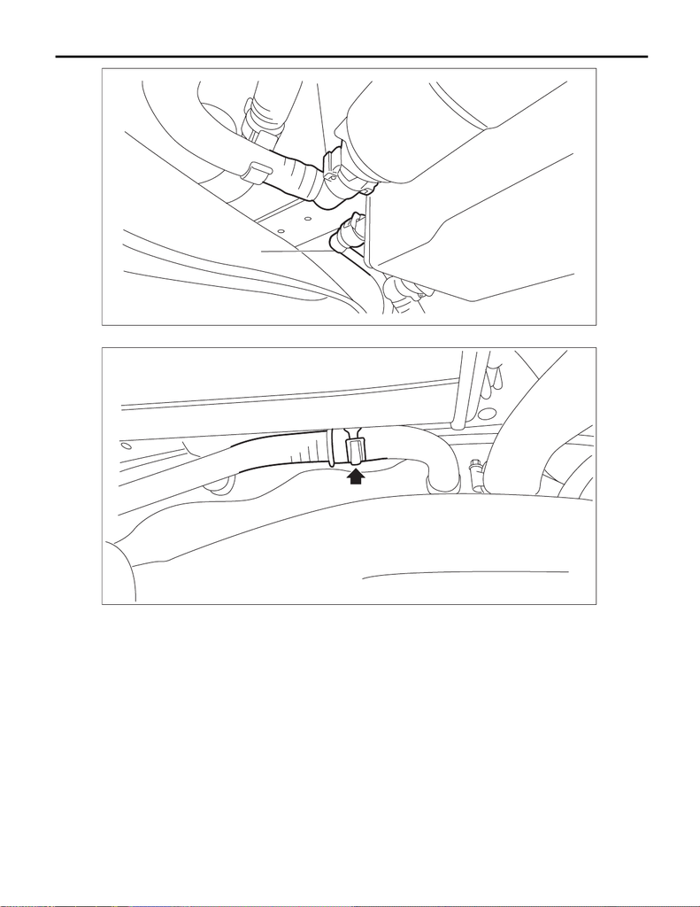

EC(STI)-18

Canister

EMISSION CONTROL (AUX. EMISSION CONTROL DEVICES)

7) Connect the vent tube to the vent hose.

(A)

(B)

EC-03423

EC-03422

15WRX_STI_US_EN.book 18 ページ ２０１５年２月１３日 金曜日 午前１１時２０分

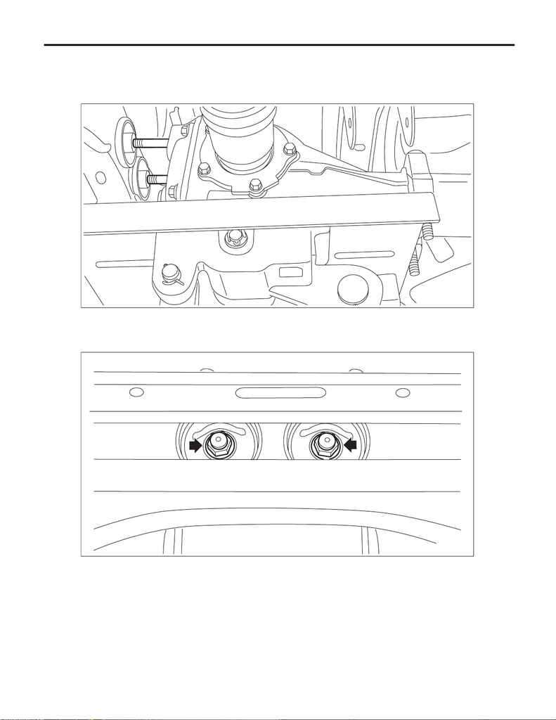

EC(STI)-19

Canister

EMISSION CONTROL (AUX. EMISSION CONTROL DEVICES)

8) Lift up the transmission jack gradually, and set the rear differential to the rear sub frame assembly.

NOTE:

When inserting the stud bolt into the bushing portion of the rear sub frame assembly, adjust the angle and lo-

cation of transmission jack and jack stand.

9) Temporarily tighten the self-locking nuts which hold the rear differential to the rear sub frame assembly.

NOTE:

Use a new self-locking nut.

EC-03320

EC-03420

15WRX_STI_US_EN.book 19 ページ ２０１５年２月１３日 金曜日 午前１１時２０分

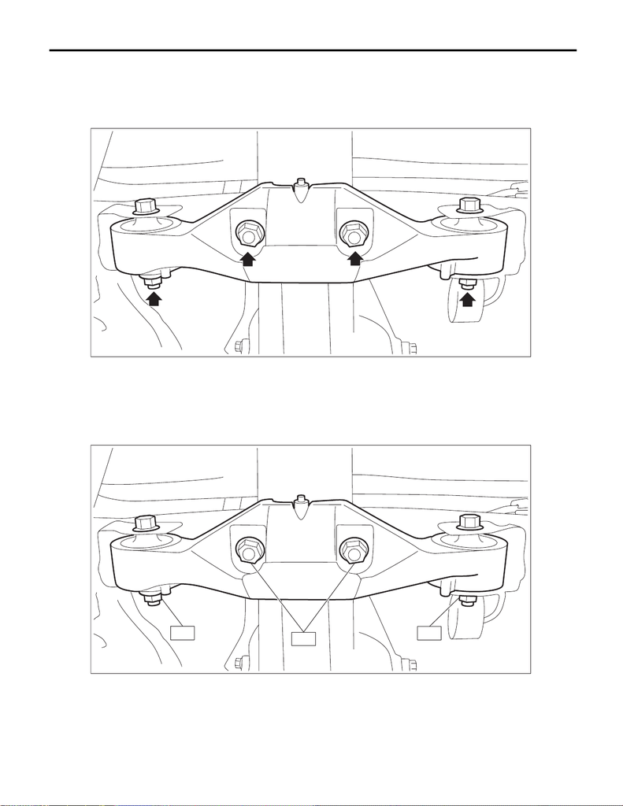

EC(STI)-20

Canister

EMISSION CONTROL (AUX. EMISSION CONTROL DEVICES)

10) Set the rear differential member to the rear sub frame assembly and rear differential, and temporarily

tighten the self-lock nuts which secure the rear differential member to the rear sub frame assembly and rear

differential.

NOTE:

Use a new self-locking nut.

11) Remove the transmission jack from the rear differential.

12) Tighten the self-locking nuts which secure the rear differential member to the rear sub frame assembly

and rear differential.

Tightening torque:

T1: 50 N·m (5.1 kgf-m, 36.9 ft-lb)

T2: 110 N·m (11.2 kgf-m, 81.1 ft-lb)

EC-03453

EC-03444

T1

T2

T2

15WRX_STI_US_EN.book 20 ページ ２０１５年２月１３日 金曜日 午前１１時２０分

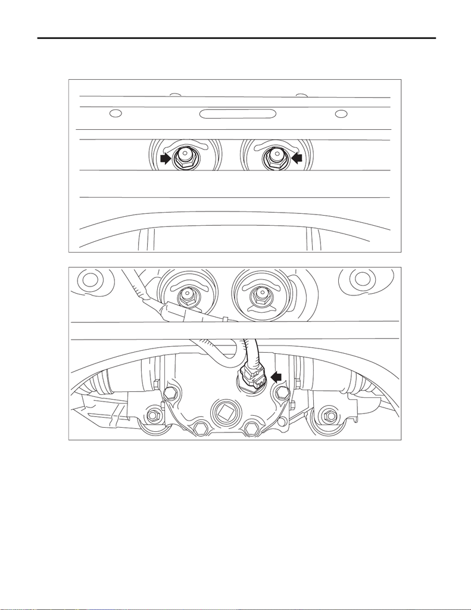

EC(STI)-21

Canister

EMISSION CONTROL (AUX. EMISSION CONTROL DEVICES)

13) Tighten the self-locking nuts which secure the rear differential to the rear sub frame assembly.

Tightening torque:

70 N·m (7.1 kgf-m, 51.6 ft-lb)

14) Connect the connector to the oil temperature sensor.

15) Install the propeller shaft. <Ref. to DS-14, INSTALLATION, Propeller Shaft.>

16) Install the rear exhaust pipe. <Ref. to EX(STI)-12, INSTALLATION, Rear Exhaust Pipe.>

17) Lower the vehicle.

18) Connect the ground terminal to the battery.

C: INSPECTION

1) Check that the canister has no deformation, cracks or other damages.

2) Check that the tube has no cracks, damage or loose part.

EC-03420

EC-03445

15WRX_STI_US_EN.book 21 ページ ２０１５年２月１３日 金曜日 午前１１時２０分